# homework4

##### 1.

$l(\beta)=\sum_{i=1}^N\left\{y_ilogp(x_i;\beta)+(1-y_i)log(1-p(x_i;\beta))\right\}=y_ix_i^T\beta-y_ilog(1+e^{x_i^T\beta})$  
Thus, we have $\frac{\partial l(\beta)}{\partial \beta}=\sum_{i=1}^Ny_ix_i - \frac{x_ie^{x_i^T\beta}}{1+e^{x_i^T\beta}}=\sum_{i=1}^N(y_i-p_i)x_i$  
So, $\frac{\partial ^2l(\beta)}{\partial \beta \partial \beta^T}=\sum_{i=1}^N-x_i\frac{\partial p_i}{\partial \beta^T}=\sum_{i=1}^N\frac{-x_ix_i^Te^{x_i^T\beta}}{(1+e^{x_i^T\beta})^2}=\sum_{i=1}^N-p_i(1-p_i)x_ix_i^T(p_i=p(x_i;\beta))$

[output not shown]

[output cut: 27 more lines]

[output not shown]

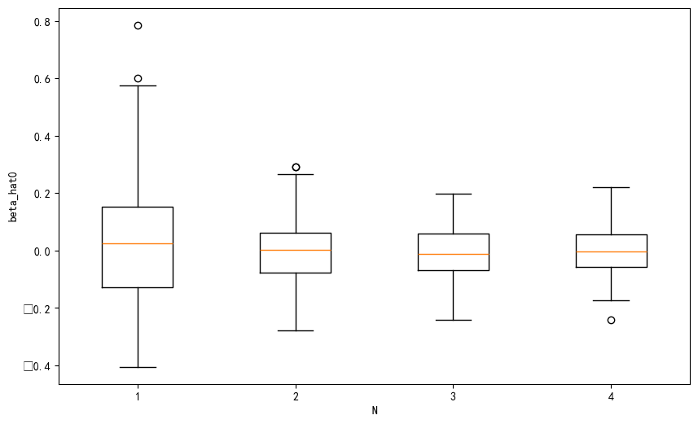

[output not shown]

[output cut: 27 more lines]

[output not shown]

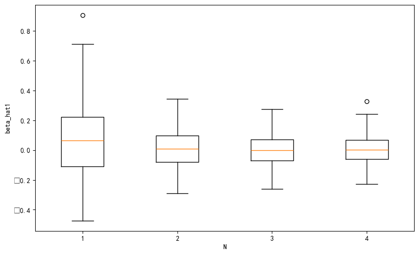

[output not shown]

[output cut: 33 more lines]

[output not shown]

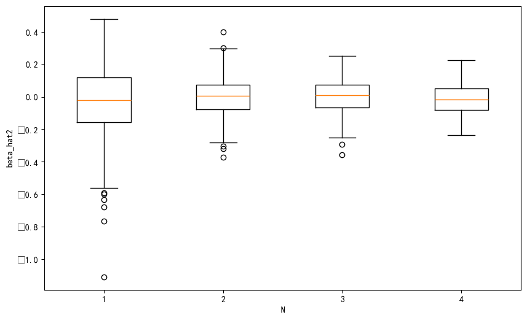

```python
import matplotlib.pyplot as plt
import numpy as np
import pandas as pd

def generate_data(N, true_beta):
    X_1 = np.random.normal(size=N)
    X_2 = np.random.normal(size=N)
    X = np.column_stack((np.ones(N), X_1, X_2))
    p = 1 / (1 + np.exp(-X @ true_beta))
    y = np.random.binomial(1, p)

    return X, y

def newton(X, y, times=30, tolerence=1e-5):
    beta = np.zeros(X.shape[1])
    for _ in range(times):
        p_hat = 1 / (1 + np.exp(-X @ beta))
        partial_one = X.T @ (y - p_hat)
        partial_two = -X.T @ np.diag(p_hat * (1 - p_hat)) @ X
        beta_new = beta - np.linalg.solve(partial_two, partial_one)

        if np.max(np.abs(beta_new - beta)) < tolerence:
            beta = beta_new
            break
        beta = beta_new

    return beta

np.random.seed(3047)
true_beta = np.array([0.5, 1.2, -1])
N_list = [200, 500, 800, 1000]
round = 200

estimate = []
for N in N_list:
    estimate_list = []
    for r in range(round):
        X, y = generate_data(N, true_beta)
        estimate_list.append(newton(X, y))

    estimate.append(np.array(estimate_list))

for s in range(3):
    results = []
    for i, N in enumerate(N_list):
        error = estimate[i][:,s] - true_beta[s]
        results.append(error)


    plt.figure(figsize=(10, 6))
    plt.boxplot(results, label=N_list)
    plt.xlabel('N')
    plt.ylabel(f'beta_hat{s}')
    plt.show()
```

##### (2).Proof:

It's easy to see that $AUC=1-l_{rank}=\frac{1}{m^+m^-}\sum_{x^+\in D^+} \sum_{x^-\in D^-}(I(f(x^+)<f(x^-)))=\frac{1}{m^+m^-}\sum_{x^+\in D^+} \sum_{x^-\in D^-}(I(f(x^+)>f(x^-)))$  
For finite samples:  
Sort all prediction scores to get thresholds $t_1 < t_2 < \dots < t_{m_+ + m_-}$.  
For each threshold $t_i$, compute $(\text{FPR}(t_i), \text{TPR}(t_i))$.  
Calculate ROC area via trapezoidal rule (sum areas of adjacent vertex trapezoids).  
The ROC area simplifies to counting "positive scores $>$ negative scores" pairs. This matches Equation.

[output not shown]

[output cut: 31 more lines]

[output not shown]

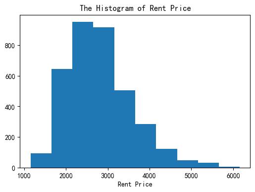

[output not shown]

[output cut: 69 more lines]

[output not shown]

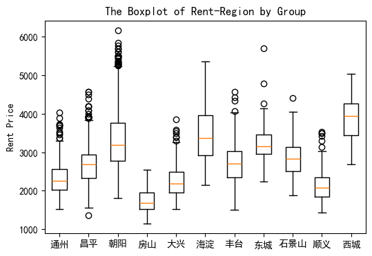

```python
"(1)"
import pandas as pd
import matplotlib.pyplot as plt
plt.rcParams["font.family"] = ["SimHei", "WenQuanYi Micro Hei", "Heiti TC"]

traindata = pd.read_csv("train_data.csv", encoding="utf-8")
testdata = pd.read_csv("test_data.csv", encoding="utf-8")

headers = traindata.columns.tolist()
headers.remove('rent')

plt.figure(figsize=(6, 4))
plt.hist(x = traindata["rent"])
plt.title("The Histogram of Rent Price")
plt.xlabel("Rent Price")
plt.show()

region_dic = {}
for region, rent in zip(traindata["region"], traindata["rent"]):
    if region not in region_dic:
        region_dic[region] = [rent]
    else:
        region_dic[region].append(rent)

data = [region_dic[place] for place in region_dic]
label = [place for place in region_dic]

plt.figure(figsize=(6, 4))
plt.boxplot(data, labels = label)
plt.title("The Boxplot of Rent-Region by Group")
plt.ylabel("Rent Price")
plt.show()
```

简要解读： 从房价中位数上看，西城最高，房山最低。朝阳区租金6000元以上的房子比其他区多。

```python
import numpy as np

traindata_dummies = pd.get_dummies(traindata, columns = ["room", "heating", 'floor_grp', "subway", 'region'], drop_first=True)
headers = traindata_dummies.columns.tolist()
headers.remove("rent")
testdata_dummies = pd.get_dummies(testdata, columns = ["room", "heating", 'floor_grp', "subway", 'region'], drop_first=True)
traindata_dummies = traindata_dummies.drop(columns = 'rent', axis=1)
X_train = np.c_[np.ones(len(traindata_dummies)), traindata_dummies]
testdata_dummies = testdata_dummies.drop(columns = 'rent', axis=1)
X_test = np.c_[np.ones(len(testdata_dummies)), testdata_dummies]
X_train = X_train.astype(np.float64)
X_test = X_test.astype(np.float64)

XTX = X_train.T @ X_train
XTy = X_train.T @ traindata['rent']
betahat = np.linalg.inv(XTX) @ XTy
y_train_pred = X_train @ betahat
y_test_pred = X_test @ betahat

def mse(y_true, y_pred):
    return np.mean((y_pred - y_true) ** 2)

train_mse = mse(y_train_pred, traindata["rent"])
print(f"The Error in the Trainset:{train_mse:.3f}")
print(f"Model: rent=", betahat[0], "+", " + ".join([f"{betahat[i+1]}*{headers[i]}" for i in range(len(betahat)-1)]))
```

[output not shown]

```
λ = 0.0000, MSE = 202798.2401
λ = 1.0000, MSE = 203066.8898
λ = 2.0000, MSE = 203629.6346
λ = 3.0000, MSE = 204282.0700
λ = 4.0000, MSE = 204947.9533
λ = 5.0000, MSE = 205598.4731
λ = 6.0000, MSE = 206223.7224
λ = 7.0000, MSE = 206821.6022
λ = 8.0000, MSE = 207393.2090
λ = 9.0000, MSE = 207940.8372
λ = 10.0000, MSE = 208467.0991
λ = 11.0000, MSE = 208974.5436
λ = 12.0000, MSE = 209465.5040
λ = 13.0000, MSE = 209942.0498
λ = 14.0000, MSE = 210405.9873
λ = 15.0000, MSE = 210858.8793
λ = 16.0000, MSE = 211302.0724
λ = 17.0000, MSE = 211736.7250
λ = 18.0000, MSE = 212163.8338
λ = 19.0000, MSE = 212584.2567
λ = 20.0000, MSE = 212998.7338
λ = 21.0000, MSE = 213407.9045
λ = 22.0000, MSE = 213812.3225
λ = 23.0000, MSE = 214212.4681
λ = 24.0000, MSE = 214608.7593
λ = 25.0000, MSE = 215001.5604
λ = 26.0000, MSE = 215391.1897
λ = 27.0000, MSE = 215777.9259
λ = 28.0000, MSE = 216162.0137
λ = 29.0000, MSE = 216543.6683
λ = 30.0000, MSE = 216923.0792
λ = 31.0000, MSE = 217300.4138
λ = 32.0000, MSE = 217675.8202
λ = 33.0000, MSE = 218049.4297
λ = 34.0000, MSE = 218421.3587
λ = 35.0000, MSE = 218791.7109
λ = 36.0000, MSE = 219160.5786
λ = 37.0000, MSE = 219528.0440
λ = 38.0000, MSE = 219894.1807
λ = 39.0000, MSE = 220259.0545
λ = 40.0000, MSE = 220622.7244
λ = 41.0000, MSE = 220985.2432
λ = 42.0000, MSE = 221346.6585
λ = 43.0000, MSE = 221707.0130
λ = 44.0000, MSE = 222066.3451
λ = 45.0000, MSE = 222424.6896
λ = 46.0000, MSE = 222782.0777
```

[output not shown]

```
λ = 47.0000, MSE = 223138.5378
λ = 48.0000, MSE = 223494.0953
λ = 49.0000, MSE = 223848.7736
```

[output not shown]

[output cut: 22 more lines]

[output not shown]

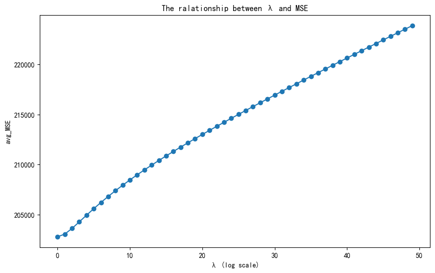

```
Best λ: 0.0000
```

```python
from sklearn.model_selection import KFold

def ridge(X, y, lambda_para):
    n = X.shape[1]
    beta_ridge = np.linalg.inv(X.T @ X + lambda_para * np.eye(n)) @ X.T @ y
    return beta_ridge

def cross_validation(X, y, lambda_paras, k=10):
    kf = KFold(n_splits=k, shuffle=True, random_state=42)
    mse_score = []

    for lambda_para in lambda_paras:
        mse_list = []
        for train_idx, val_idx in kf.split(X):
            X_train, X_val = X[train_idx], X[val_idx]
            y_train, y_val = y[train_idx], y[val_idx]
            beta = ridge(X_train, y_train, lambda_para)

            y_pred = X_val @ beta
            mse = np.mean((y_pred - y_val) ** 2)
            mse_list.append(mse)

        avg_mse = np.mean(mse_list)
        mse_score.append(avg_mse)
        print(f"λ = {lambda_para:.4f}, MSE = {avg_mse:.4f}")

    plt.figure(figsize=(10, 6))
    plt.plot(lambda_paras, mse_score, 'o-')
    plt.xlabel('λ (log scale)')
    plt.ylabel('avg_MSE')
    plt.title('The ralationship between λ and MSE')
    plt.savefig('lambda_vs_mse.png')
    plt.show()

    best_idx = np.argmin(mse_score)
    best_lambda = lambda_paras[best_idx]
    print(f"Best λ: {best_lambda:.4f}")

    return best_lambda

train_best = cross_validation(X_train, traindata["rent"], lambda_paras=range(50))
```

```python
best_beta = ridge(X_train, traindata["rent"], train_best)
print(f"Final Model: rent=", best_beta[0], "+", " + ".join([f"{best_beta[i+1]}*{headers[i]}" for i in range(len(best_beta)-1)]))

y_test_pred = X_test @ best_beta
test_mse = mse(y_test_pred, testdata["rent"])
print(f'MSE of testdata :{test_mse:.3f}')
```

[output not shown]